# 18 Expressions

2023-07-03

## 18.1 Introduction

```r
y <- x * 10
```

```
## Error in eval(expr, envir, enclos): object 'x' not found
```

```r
z <- rlang::expr(y <- x * 10)
z
```

```
## y <- x * 10
```

```r
x <- 4
eval(z)
y
```

```
## [1] 40
```

## 18.2 Abstract syntax trees

### 18.2.1 Drawing

```r
lobstr::ast(f(x, "y", 1))
```

```
## █─f
## ├─x
## ├─"y"
## └─1
```

```r
lobstr::ast(f(g(1, 2), h(3, 4, i())))
```

```
## █─f
## ├─█─g
## │ ├─1
## │ └─2
## └─█─h
##   ├─3
##   ├─4
##   └─█─i
```

### 18.2.2 Non-code components

```r
ast(
  f(x,  y)  # important!
)
```

```
## █─f
## ├─x
## └─y
```

```r
lobstr::ast(y <- x)
```

```
## █─`<-`
## ├─y
## └─x
```

```r
lobstr::ast(y < -x)
```

```
## █─`<`
## ├─y
## └─█─`-`
##   └─x
```

### 18.2.3 Infix calls

```r
y <- x * 10
`<-`(y, `*`(x, 10))
y
```

```
## [1] 40
```

```r
lobstr::ast(y <- x * 10)
```

```
## █─`<-`
## ├─y
## └─█─`*`
##   ├─x
##   └─10
```

```r
expr(`<-`(y, `*`(x, 10)))
```

```
## y <- x * 10
```

### 18.2.4 Exercises

```r
# 1
f(g(h()))

# 2
1 + 2 + 3

# 3
(x + y) * z
```

2. Draw the following trees by hand and then check your answers with `lobstr::ast()`.

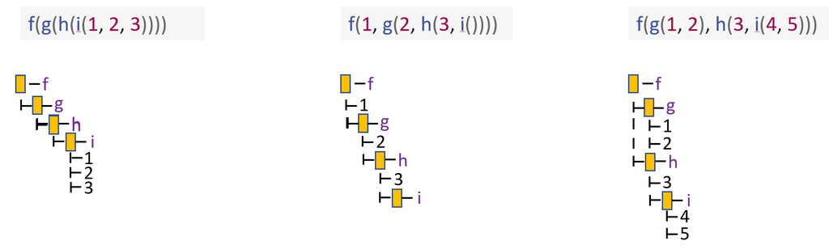

ast_trees

3. What’s happening with the ASTs below? (Hint: carefully read `?"^"`.)

```r
lobstr::ast(`x` + `y`)
```

```
## █─`+`
## ├─x
## └─y
```

Function `+` is being called with the symbols `x` and `y`

```r
lobstr::ast(x ** y)
```

```
## █─`^`
## ├─x
## └─y
```

Function `**` which is equal to `^` is being called with the symbols `x` and `y`

```r
lobstr::ast(1 -> x)
```

```
## █─`<-`
## ├─x
## └─1
```

Function `<-` is being called on symbol `x` and assigning it the value of 1. In this case the assignment arrow gets flipped the other direction

4. What is special about the AST below? (Hint: re-read Section 6.2.1.)

```r
lobstr::ast(function(x = 1, y = 2) {})
```

```
## █─`function`
## ├─█─x = 1
## │ └─y = 2
## ├─█─`{`
## └─<inline srcref>
```

x and y are now italicized to mean they are the default values. Inside { is empty but has a place holder

5. What does the call tree of an `if` statement with multiple `else if` conditions look like? Why?

```r
lobstr::ast(if(x == 1) {} else if(x == 2) {} else if(x == 3) {} else {})
```

```
## █─`if`
## ├─█─`==`
## │ ├─x
## │ └─1
## ├─█─`{`
## └─█─`if`
##   ├─█─`==`
##   │ ├─x
##   │ └─2
##   ├─█─`{`
##   └─█─`if`
##     ├─█─`==`
##     │ ├─x
##     │ └─3
##     ├─█─`{`
##     └─█─`{`
```

Each if is nested inside the one above it. It looks this way because the interior else if do not run if the above if returns TRUE.

## 18.3 Expressions

### 18.3.1 Constants

```r
identical(expr(TRUE), TRUE)
```

```
## [1] TRUE
```

```r
identical(expr(1), 1)
```

```
## [1] TRUE
```

```r
identical(expr(2L), 2L)
```

```
## [1] TRUE
```

```r
identical(expr("x"), "x")
```

```
## [1] TRUE
```

### 18.3.2 Symbols

```r
expr(x)
```

```
## x
```

```r
sym("x")
```

```
## x
```

```r
as_string(expr(x))
```

```
## [1] "x"
```

```r
str(expr(x))
```

```
##  symbol x
```

```r
is.symbol(expr(x))
```

```
## [1] TRUE
```

### 18.3.3 Calls

```r
lobstr::ast(read.table("important.csv", row.names = FALSE))
```

```
## █─read.table
## ├─"important.csv"
## └─row.names = FALSE
```

```r
x <- expr(read.table("important.csv", row.names = FALSE))

typeof(x)
```

```
## [1] "language"
```

```r
is.call(x)
```

```
## [1] TRUE
```

#### 18.3.3.1 Subsetting

```r
x[[1]]
```

```
## read.table
```

```r
is.symbol(x[[1]])
```

```
## [1] TRUE
```

```r
as.list(x[-1])
```

```
## [[1]]
## [1] "important.csv"
##
## $row.names
## [1] FALSE
```

```r
x[[2]]
```

```
## [1] "important.csv"
```

```r
x$row.names
```

```
## [1] FALSE
```

```r
length(x) - 1
```

```
## [1] 2
```

```r
rlang::call_standardise(x)
```

```
## read.table(file = "important.csv", row.names = FALSE)
```

```r
x$header <- TRUE
x
```

```
## read.table("important.csv", row.names = FALSE, header = TRUE)
```

#### 18.3.3.2 Function position

```r
lobstr::ast(foo())
```

```
## █─foo
```

```r
lobstr::ast("foo"())
```

```
## █─foo
```

```r
lobstr::ast(pkg::foo(1))
```

```
## █─█─`::`
## │ ├─pkg
## │ └─foo
## └─1
```

```r
lobstr::ast(obj$foo(1))
```

```
## █─█─`$`
## │ ├─obj
## │ └─foo
## └─1
```

```r
lobstr::ast(foo(1)(2))
```

```
## █─█─foo
## │ └─1
## └─2
```

### 18.3.3.3 Constructing

```r
call2("mean", x = expr(x), na.rm = TRUE)
```

```
## mean(x = x, na.rm = TRUE)
```

```r
call2(expr(base::mean), x = expr(x), na.rm = TRUE)
```

```
## base::mean(x = x, na.rm = TRUE)
```

```r
call2("<-", expr(x), 10)
```

```
## x <- 10
```

### 18.3.4 Summary

### 18.3.5 Exercises

1. Which two of the six types of atomic vector can’t appear in an expression? Why? Similarly, why can’t you create an expression that contains an atomic vector of length greater than one?

Raw and Complex. You need to use a function to create them. Use also need a function in order to create an atomic vector of length greater than 1.

2. What happens when you subset a call object to remove the first element? e.g. `expr(read.csv("foo.csv", header = TRUE))[-1]`. Why?

```r
x <- expr(read.csv("foo.csv", header = TRUE))
x
```

```
## read.csv("foo.csv", header = TRUE)
```

```r
x[-1]
```

```
## "foo.csv"(header = TRUE)
```

The first object in the expression vector is the function. In this case “foo.csv” becomes the new function since it is in position 1

3. Describe the differences between the following call objects.

```r
x <- 1:10
```

```r
call2(median, x, na.rm = TRUE)
```

```
## (function (x, na.rm = FALSE, ...)
## UseMethod("median"))(1:10, na.rm = TRUE)
```

```r
call2(expr(median), x, na.rm = TRUE)
```

```
## median(1:10, na.rm = TRUE)
```

```r
call2(median, expr(x), na.rm = TRUE)
```

```
## (function (x, na.rm = FALSE, ...)
## UseMethod("median"))(x, na.rm = TRUE)
```

```r
call2(expr(median), expr(x), na.rm = TRUE)
```

```
## median(x, na.rm = TRUE)
```

The first has useMethod(median) and 1:10, in this case both median and x are evaluated. The second one evaluates x but not median. The third evaluates median but not x. The last does not evaluate median or x. All will evaluate the same once called, but the binding of the symbols occur at different times.

4. `rlang::call_standardise()` doesn’t work so well for the following calls. Why? What makes mean() special?

```r
call_standardise(quote(mean(1:10, na.rm = TRUE)))
```

```
## mean(x = 1:10, na.rm = TRUE)
```

```r
call_standardise(quote(mean(n = T, 1:10)))
```

```
## mean(x = 1:10, n = T)
```

```r
call_standardise(quote(mean(x = 1:10, , TRUE)))
```

```
## mean(x = 1:10, , TRUE)
```

Mean only takes one mandatory argument, `x`, but also has `...` which can’t be standardized. Therefore it includes it as is.

5. Why does this code not make sense?

```r
x <- expr(foo(x = 1))
x
```

```
## foo(x = 1)
```

```r
names(x)
```

```
## [1] ""  "x"
```

```r
lobstr::ast(foo(x = 1))
```

```
## █─foo
## └─x = 1
```

```r
names(x) <- c("x", "y")
x
```

```
## foo(y = 1)
```

```r
names(x)
```

```
## [1] "x" "y"
```

```r
x
```

```
## foo(y = 1)
```

The original names of x are “” and “x”. We then change them to “x”, and “y”. In this case we are changing the name of x to y since x is the second element of the call. The first element name is irrelevant since it’s the function.

6. Construct the expression `if(x > 1) "a" else "b"` using multiple calls to call2(). How does the code structure reflect the structure of the AST?

```r
lobstr::ast(if(x > 1) "a" else "b")
```

```
## █─`if`
## ├─█─`>`
## │ ├─x
## │ └─1
## ├─"a"
## └─"b"
```

```r
call2("if", call2(">", sym("x"), 1), "a", "b")
```

```
## if (x > 1) "a" else "b"
```

```r
call2("if", call2(">", expr(x), 1), "a", "b")
```

```
## if (x > 1) "a" else "b"
```

```r
# Have wrap x in sym or expr otherwise x gets evaluated
```

```r
call2("if", call2(">", x, 1), "a", "b")
```

```
## if (foo(y = 1) > 1) "a" else "b"
```

Comparison gets called inside of the if statement and result determines return value.

## 18.4 Parsing and grammar

### 18.4.1 Operator precedence

```r
lobstr::ast(1 + 2 * 3)
```

```
## █─`+`
## ├─1
## └─█─`*`
##   ├─2
##   └─3
```

```r
lobstr::ast(!x %in% y)
```

```
## █─`!`
## └─█─`%in%`
##   ├─x
##   └─y
```

```r
lobstr::ast((1 + 2) * 3)
```

```
## █─`*`
## ├─█─`(`
## │ └─█─`+`
## │   ├─1
## │   └─2
## └─3
```

### 18.4.2 Associativity

```r
lobstr::ast(1 + 2 + 3)
```

```
## █─`+`
## ├─█─`+`
## │ ├─1
## │ └─2
## └─3
```

```r
lobstr::ast(2^2^3)
```

```
## █─`^`
## ├─2
## └─█─`^`
##   ├─2
##   └─3
```

```r
lobstr::ast(x <- y <- z)
```

```
## █─`<-`
## ├─x
## └─█─`<-`
##   ├─y
##   └─z
```

### 18.4.3 Parsing and deparsing

```r
x1 <- "y <- x + 10"
x1
```

```
## [1] "y <- x + 10"
```

```r
is.call(x1)
```

```
## [1] FALSE
```

```r
x2 <- rlang::parse_expr(x1)
x2
```

```
## y <- x + 10
```

```r
is.call(x2)
```

```
## [1] TRUE
```

```r
x3 <- "a <- 1; a + 1"
rlang::parse_exprs(x3)
```

```
## [[1]]
## a <- 1
##
## [[2]]
## a + 1
```

```r
as.list(parse(text = x1))
```

```
## [[1]]
## y <- x + 10
```

```r
z <- expr(y <- x + 10)
expr_text(z)
```

```
## [1] "y <- x + 10"
```

```r
cat(expr_text(expr({
  # This is a comment
  x <-             `x` + 1
})))
```

```
## {
##     x <- x + 1
## }
```

### 18.4.4 Exercises

1. R uses parentheses in two slightly different ways as illustrated by these two calls:

```r
lobstr::ast(f((1)))
```

```
## █─f
## └─█─`(`
##   └─1
```

```r
lobstr::ast(`(`(1 + 1))
```

```
## █─`(`
## └─█─`+`
##   ├─1
##   └─1
```

Huh? In first it’s inside of f and in the second it ignores the one of the (

2. `=` can also be used in two ways. Construct a simple example that shows both uses.

```r
lobstr::ast(f(x = 2))
```

```
## █─f
## └─x = 2
```

```r
lobstr::ast(`=`(x = 2))
```

```
## █─`=`
## └─x = 2
```

3. Does `-2^2` yield 4 or -4? Why?

```r
# -4, Exponents come first
lobstr::ast(-2^2)
```

```
## █─`-`
## └─█─`^`
##   ├─2
##   └─2
```

```r
-2^2
```

```
## [1] -4
```

4. What does `!1 + !1` return? Why?

```r
# FALSE, negate 1 (FALSE), add 1 (1 / TRUE), negate result (FALSE)
lobstr::ast(!1 + !1)
```

```
## █─`!`
## └─█─`+`
##   ├─1
##   └─█─`!`
##     └─1
```

```r
!1 + !1
```

```
## [1] FALSE
```

5. Why does `x1 <- x2 <- x3 <- 0` work? Describe the two reasons.

```r
lobstr::ast(x1 <- x2 <- x3 <- 0)
```

```
## █─`<-`
## ├─x1
## └─█─`<-`
##   ├─x2
##   └─█─`<-`
##     ├─x3
##     └─0
```

3 Steps are occurring. 0 is assigned to x3, x3 is assigned to x2, and x2 is assigned to x1. It all happens in order from right to left

6. Compare the ASTs of `x + y %+% z` and `x ^ y %+% z`. What have you learned about the precedence of custom infix functions?

```r
lobstr::ast(x + y %+% z)
```

```
## █─`+`
## ├─x
## └─█─`%+%`
##   ├─y
##   └─z
```

```r
lobstr::ast(x ^ y %+% z)
```

```
## █─`%+%`
## ├─█─`^`
## │ ├─x
## │ └─y
## └─z
```

Custom infixes come before addition, but after exponents

7. What happens if you call `parse_expr()` with a string that generates multiple expressions? e.g. `parse_expr("x + 1; y + 1")`

```r
parse_expr("x + 1; y + 1")
```

```
## Error in `parse_expr()`:
## ! `x` must contain exactly 1 expression, not 2.
```

You get an error. It takes only 1 expression

8. What happens if you attempt to parse an invalid expression? e.g. “a +” or “f())”.

```r
parse_expr("a +")
```

```
## Error in parse(text = x, keep.source = FALSE): <text>:2:0: unexpected end of input
## 1: a +
##    ^
```

```r
parse_expr("f())")
```

```
## Error in parse(text = x, keep.source = FALSE): <text>:1:4: unexpected ')'
## 1: f())
##        ^
```

You get an error

9. `deparse()` produces vectors when the input is long. For example, the following call produces a vector of length two:

```r
expr <- expr(g(a + b + c + d + e + f + g + h + i + j + k + l +
  m + n + o + p + q + r + s + t + u + v + w + x + y + z))

deparse(expr)
```

```
## [1] "g(a + b + c + d + e + f + g + h + i + j + k + l + m + n + o + "
## [2] "    p + q + r + s + t + u + v + w + x + y + z)"
```

What does `expr_text()` do instead?

```r
expr_text(expr)
```

```
## [1] "g(a + b + c + d + e + f + g + h + i + j + k + l + m + n + o + \n    p + q + r + s + t + u + v + w + x + y + z)"
```

Doesn’t fuck it up, but adds in a newline character while making it a vector of length 1

10. `pairwise.t.test()` assumes that deparse() always returns a length one character vector. Can you construct an input that violates this expectation? What happens?

```r
#Normal case
pairwise.t.test(airquality$Ozone, as.factor(airquality$Month))
```

```
##
##  Pairwise comparisons using t tests with pooled SD
##
## data:  airquality$Ozone and as.factor(airquality$Month)
##
##   5       6       7       8
## 6 1.00000 -       -       -
## 7 0.00026 0.05113 -       -
## 8 0.00019 0.04987 1.00000 -
## 9 1.00000 1.00000 0.00488 0.00388
##
## P value adjustment method: holm
```

```r
# Broken
deparse(c(airquality$Ozone, as.factor(airquality$Month)))
```

```
##  [1] "c(41L, 36L, 12L, 18L, NA, 28L, 23L, 19L, 8L, NA, 7L, 16L, 11L, "
##  [2] "14L, 18L, 14L, 34L, 6L, 30L, 11L, 1L, 11L, 4L, 32L, NA, NA, NA, "
##  [3] "23L, 45L, 115L, 37L, NA, NA, NA, NA, NA, NA, 29L, NA, 71L, 39L, "
##  [4] "NA, NA, 23L, NA, NA, 21L, 37L, 20L, 12L, 13L, NA, NA, NA, NA, "
##  [5] "NA, NA, NA, NA, NA, NA, 135L, 49L, 32L, NA, 64L, 40L, 77L, 97L, "
##  [6] "97L, 85L, NA, 10L, 27L, NA, 7L, 48L, 35L, 61L, 79L, 63L, 16L, "
##  [7] "NA, NA, 80L, 108L, 20L, 52L, 82L, 50L, 64L, 59L, 39L, 9L, 16L, "
##  [8] "78L, 35L, 66L, 122L, 89L, 110L, NA, NA, 44L, 28L, 65L, NA, 22L, "
##  [9] "59L, 23L, 31L, 44L, 21L, 9L, NA, 45L, 168L, 73L, NA, 76L, 118L, "
## [10] "84L, 85L, 96L, 78L, 73L, 91L, 47L, 32L, 20L, 23L, 21L, 24L, 44L, "
## [11] "21L, 28L, 9L, 13L, 46L, 18L, 13L, 24L, 16L, 13L, 23L, 36L, 7L, "
## [12] "14L, 30L, NA, 14L, 18L, 20L, 1L, 1L, 1L, 1L, 1L, 1L, 1L, 1L, "
## [13] "1L, 1L, 1L, 1L, 1L, 1L, 1L, 1L, 1L, 1L, 1L, 1L, 1L, 1L, 1L, 1L, "
## [14] "1L, 1L, 1L, 1L, 1L, 1L, 1L, 2L, 2L, 2L, 2L, 2L, 2L, 2L, 2L, 2L, "
## [15] "2L, 2L, 2L, 2L, 2L, 2L, 2L, 2L, 2L, 2L, 2L, 2L, 2L, 2L, 2L, 2L, "
## [16] "2L, 2L, 2L, 2L, 2L, 3L, 3L, 3L, 3L, 3L, 3L, 3L, 3L, 3L, 3L, 3L, "
## [17] "3L, 3L, 3L, 3L, 3L, 3L, 3L, 3L, 3L, 3L, 3L, 3L, 3L, 3L, 3L, 3L, "
## [18] "3L, 3L, 3L, 3L, 4L, 4L, 4L, 4L, 4L, 4L, 4L, 4L, 4L, 4L, 4L, 4L, "
## [19] "4L, 4L, 4L, 4L, 4L, 4L, 4L, 4L, 4L, 4L, 4L, 4L, 4L, 4L, 4L, 4L, "
## [20] "4L, 4L, 4L, 5L, 5L, 5L, 5L, 5L, 5L, 5L, 5L, 5L, 5L, 5L, 5L, 5L, "
## [21] "5L, 5L, 5L, 5L, 5L, 5L, 5L, 5L, 5L, 5L, 5L, 5L, 5L, 5L, 5L, 5L, "
## [22] "5L)"
```

```r
pairwise.t.test(c(airquality$Ozone, airquality$Ozone),
                c(as.factor(airquality$Month), as.factor(airquality$Month)))
```

```
##
##  Pairwise comparisons using t tests with pooled SD
##
## data:  c(airquality$Ozone, airquality$Ozone) and c(as.factor(airquality$Month), as.factor(airquality$Month))
##
##   5       6       7       8
## 6 1.00000 -       -       -
## 7 2.0e-08 0.00118 -       -
## 8 9.7e-09 0.00095 1.00000 -
## 9 0.63675 1.00000 8.4e-06 4.7e-06
##
## P value adjustment method: holm
```

R 4.0.0 Fixed the error

## 18.5 Walking AST with recursive functions

```r
expr_type <- function(x) {
  if (rlang::is_syntactic_literal(x)) {
    "constant"
  } else if (is.symbol(x)) {
    "symbol"
  } else if (is.call(x)) {
    "call"
  } else if (is.pairlist(x)) {
    "pairlist"
  } else {
    typeof(x)
  }
}

expr_type(expr("a"))
```

```
## [1] "constant"
```

```r
expr_type(expr(x))
```

```
## [1] "symbol"
```

```r
expr_type(expr(f(1, 2)))
```

```
## [1] "call"
```

```r
switch_expr <- function(x, ...) {
  switch(expr_type(x),
    ...,
    stop("Don't know how to handle type ", typeof(x), call. = FALSE)
  )
}
```

```r
# This is the example skeleton for the functions below
recurse_call <- function(x) {
  switch_expr(x,
    # Base cases
    symbol = ,
    constant = ,

    # Recursive cases
    call = ,
    pairlist =
  )
}
```

### 18.5.1 Finding F and T

```r
expr_type(expr(TRUE))
```

```
## [1] "constant"
```

```r
expr_type(expr(T))
```

```
## [1] "symbol"
```

```r
logical_abbr_rec <- function(x) {
  switch_expr(x,
    constant = FALSE,
    symbol = as_string(x) %in% c("F", "T")
  )
}

logical_abbr_rec(expr(TRUE))
```

```
## [1] FALSE
```

```r
logical_abbr_rec(expr(T))
```

```
## [1] TRUE
```

```r
logical_abbr <- function(x) {
  logical_abbr_rec(enexpr(x))
}

logical_abbr(T)
```

```
## [1] TRUE
```

```r
logical_abbr(FALSE)
```

```
## [1] FALSE
```

```r
logical_abbr_rec <- function(x) {
  switch_expr(x,
    # Base cases
    constant = FALSE,
    symbol = as_string(x) %in% c("F", "T"),

    # Recursive cases
    call = ,
    pairlist = purrr::some(x, logical_abbr_rec)
  )
}

logical_abbr(mean(x, na.rm = T))
```

```
## [1] TRUE
```

```r
logical_abbr(function(x, na.rm = T) FALSE)
```

```
## [1] TRUE
```

### 18.5.2 Finding all variables created by assignment

```r
ast(x <- 10)
```

```
## █─`<-`
## ├─x
## └─10
```

```r
find_assign_rec <- function(x) {
  switch_expr(x,
    constant = ,
    symbol = character()
  )
}
find_assign <- function(x) find_assign_rec(enexpr(x))

find_assign("x")
```

```
## character(0)
```

```r
find_assign(x)
```

```
## character(0)
```

```r
flat_map_chr <- function(.x, .f, ...) {
  purrr::flatten_chr(purrr::map(.x, .f, ...))
}

flat_map_chr(letters[1:3], ~ rep(., sample(3, 1)))
```

```
## [1] "a" "a" "b" "b" "b" "c"
```

```r
find_assign_rec <- function(x) {
  switch_expr(x,
    # Base cases
    constant = ,
    symbol = character(),

    # Recursive cases
    pairlist = flat_map_chr(as.list(x), find_assign_rec),
    call = {
      if (is_call(x, "<-")) {
        as_string(x[[2]])
      } else {
        flat_map_chr(as.list(x), find_assign_rec)
      }
    }
  )
}


find_assign(a <- 1)
```

```
## [1] "a"
```

```r
find_assign({
  a <- 1
  {
    b <- 2
  }
})
```

```
## [1] "a" "b"
```

```r
find_assign({
  a <- 1
  a <- 2
})
```

```
## [1] "a" "a"
```

```r
find_assign <- function(x) unique(find_assign_rec(enexpr(x)))

find_assign({
  a <- 1
  a <- 2
})
```

```
## [1] "a"
```

```r
find_assign({
  a <- b <- c <- 1
})
```

```
## [1] "a"
```

```r
find_assign_call <- function(x) {
  if (is_call(x, "<-") && is_symbol(x[[2]])) {
    lhs <- as_string(x[[2]])
    children <- as.list(x)[-1]
  } else {
    lhs <- character()
    children <- as.list(x)
  }

  c(lhs, flat_map_chr(children, find_assign_rec))
}

find_assign_rec <- function(x) {
  switch_expr(x,
    # Base cases
    constant = ,
    symbol = character(),

    # Recursive cases
    pairlist = flat_map_chr(x, find_assign_rec),
    call = find_assign_call(x)
  )
}

find_assign(a <- b <- c <- 1)
```

```
## [1] "a" "b" "c"
```

```r
find_assign(system.time(x <- print(y <- 5)))
```

```
## [1] "x" "y"
```

### 18.5.3 Exercises

1. `logical_abbr()` returns `TRUE` for `T(1, 2, 3)`. How could you modify `logical_abbr_rec()` so that it ignores function calls that use `T` or `F`?

```r
logical_abbr(T(1, 2, 3))
```

```
## [1] TRUE
```

```r
logical_abbr_rec <- function(x) {
  switch_expr(x,
    # Base cases
    constant = FALSE,
    symbol = as_string(x) %in% c("F", "T"),

    # Recursive cases
    call = {
      if (is_call(x, c("T", "F"))) {
        x <- as.list(x)[-1]
        purrr::some(x, logical_abbr_rec)
      } else {
        purrr::some(x, logical_abbr_rec)
      }
    },
    pairlist = purrr::some(x, logical_abbr_rec)
  )
}

logical_abbr(T(1, 2, 3))
```

```
## [1] FALSE
```

```r
logical_abbr(c(1, T, 3))
```

```
## [1] TRUE
```

2. `logical_abbr()` works with expressions. It currently fails when you give it a function. Why? How could you modify `logical_abbr()` to make it work? What components of a function will you need to recurse over?

```r
logical_abbr(function(x = TRUE) {
  g(x + T)
})
```

```
## [1] TRUE
```

```r
logical_abbr(function(x = TRUE) {
  F(T + T)
})
```

```
## [1] TRUE
```

Idk works for me

3. Modify `find_assign` to also detect assignment using replacement functions, i.e. `names(x) <- y`.

```r
find_assign_call <- function(x) {
  if (is_call(x, c("<-", "names")) && is_symbol(x[[2]])) {
    lhs <- as_string(x[[2]])
    children <- as.list(x)[-1]
  } else {
    lhs <- character()
    children <- as.list(x)
  }

  c(lhs, flat_map_chr(children, find_assign_rec))
}

find_assign_rec <- function(x) {
  switch_expr(x,
    # Base cases
    constant = ,
    symbol = character(),

    # Recursive cases
    pairlist = flat_map_chr(x, find_assign_rec),
    call = find_assign_call(x)
  )
}

find_assign(names(x) <- y)
```

```
## [1] "x"
```

4. Write a function that extracts all calls to a specified function.

```r
 # Stole all of this
find_assign_call <- function(x) {
  if (is_call(x)) {
    lhs <- expr_text(x)
    children <- as.list(x)[-1]
  } else {
    lhs <- character()
    children <- as.list(x)
  }

  c(lhs, flat_map_chr(children, find_assign_rec))
}

find_assign_rec <- function(x) {
  switch_expr(
    x,
    # Base cases
    constant = ,
    symbol = character(),

    # Recursive cases
    pairlist = flat_map_chr(x, find_assign_rec),
    call = find_assign_call(x)
  )
}

find_assign(x <- y)
```

```
## [1] "x <- y"
```

```r
find_assign(names(x(y)) <- y <- z)
```

```
## [1] "names(x(y)) <- y <- z" "names(x(y))"           "x(y)"
## [4] "y <- z"
```

[output not shown]

```r
find_assign(mean(sum(1:3)))
```

```
## [1] "mean(sum(1:3))" "sum(1:3)"       "1:3"
```

## 18.6 Specialised data structures

### 18.6.1 Pairlists

```r
f <- expr(function(x, y = 10) x + y)

args <- f[[2]]
args
```

```
## $x
##
##
## $y
## [1] 10
```

```r
typeof(args)
```

```
## [1] "pairlist"
```

```r
pl <- pairlist(x = 1, y = 2)
length(pl)
```

```
## [1] 2
```

```r
pl$x
```

```
## [1] 1
```

### 18.6.2 Missing arguments

```r
missing_arg()
```

```r
typeof(missing_arg())
```

```
## [1] "symbol"
```

```r
is_missing(missing_arg())
```

```
## [1] TRUE
```

```r
f <- expr(function(x, y = 10) x + y)
args <- f[[2]]
is_missing(args[[1]])
```

```
## [1] TRUE
```

```r
f <- expr(function(...) list(...))
args <- f[[2]]
is_missing(args[[1]])
```

```
## [1] TRUE
```

```r
m <- missing_arg()
m
```

```
## Error in eval(expr, envir, enclos): argument "m" is missing, with no default
```

```r
ms <- list(missing_arg(), missing_arg())
ms[[1]]
```

### 18.6.3 Expression

```r
exp1 <- parse(text = c("
x <- 4
x
"))
exp2 <- expression(x <- 4, x)

typeof(exp1)
```

```
## [1] "expression"
```

```r
typeof(exp2)
```

```
## [1] "expression"
```

```r
exp1
```

```
## expression(x <- 4, x)
```

```r
exp2
```

```
## expression(x <- 4, x)
```

```r
length(exp1)
```

```
## [1] 2
```

```r
exp1[[1]]
```

```
## x <- 4
```

```r
exp1[[2]]
```

```
## x
```